# HW3_Shaoqian_Chen

Shaoqian Chen 8831737894

2/25/2020

```r
library(forecast)
df = read.csv("hw3.csv")
```

# 1. (30 pts) An estimate of sales for Carlson Department Store had there been no hurricane

```r
carl = df[,2:6] %>%
        as.matrix %>%
        as.numeric %>%
        na.omit %>%
        as.numeric
carlts = ts(carl, start = c(2012, 9), end = c(2016, 8), frequency = 12)
carlts
```

```
##       Jan  Feb  Mar  Apr  May  Jun  Jul  Aug  Sep  Oct  Nov  Dec
## 2012                                         1.71 1.90 2.74 4.20
## 2013 1.45 1.80 2.03 1.99 2.32 2.20 2.13 2.43 1.90 2.13 2.56 4.16
## 2014 2.31 1.89 2.02 2.23 2.39 2.14 2.27 2.21 1.89 2.29 2.83 4.04
## 2015 2.31 1.99 2.42 2.45 2.57 2.42 2.40 2.50 2.09 2.54 2.97 4.35
## 2016 2.56 2.28 2.69 2.48 2.73 2.37 2.31 2.23
```

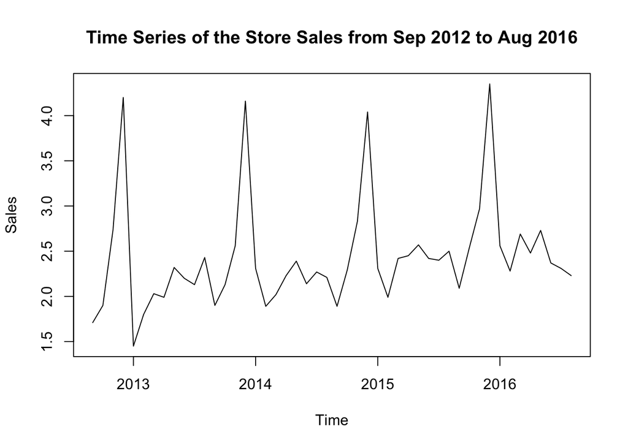

```r
plot(carlts,
     main = "Time Series of the Store Sales from Sep 2012 to Aug 2016",
     ylab = "Sales")
```

```r
model1 <- auto.arima(carlts)
model1_forecast <- forecast(model1, h = 4)
```

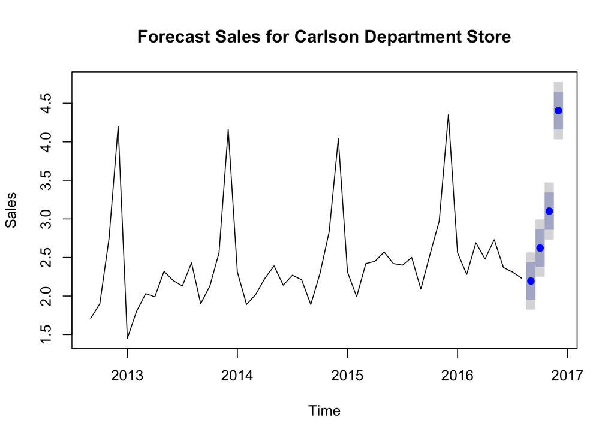

```r
plot(model1_forecast,
     main = "Forecast Sales for Carlson Department Store",
     ylab = "Sales", xlab = "Time")
```

```r
est_carlson_no_Hurr = 2.194225+2.621424+3.101586+4.404064
est_carlson_no_Hurr
```

```
## [1] 12.3213
```

## An estimatye of sales for Carlson Department had there been no hurricane would be *12.3213*

# 2. (40 pts) An estimate of county-wide department store sales had there been no hurricane

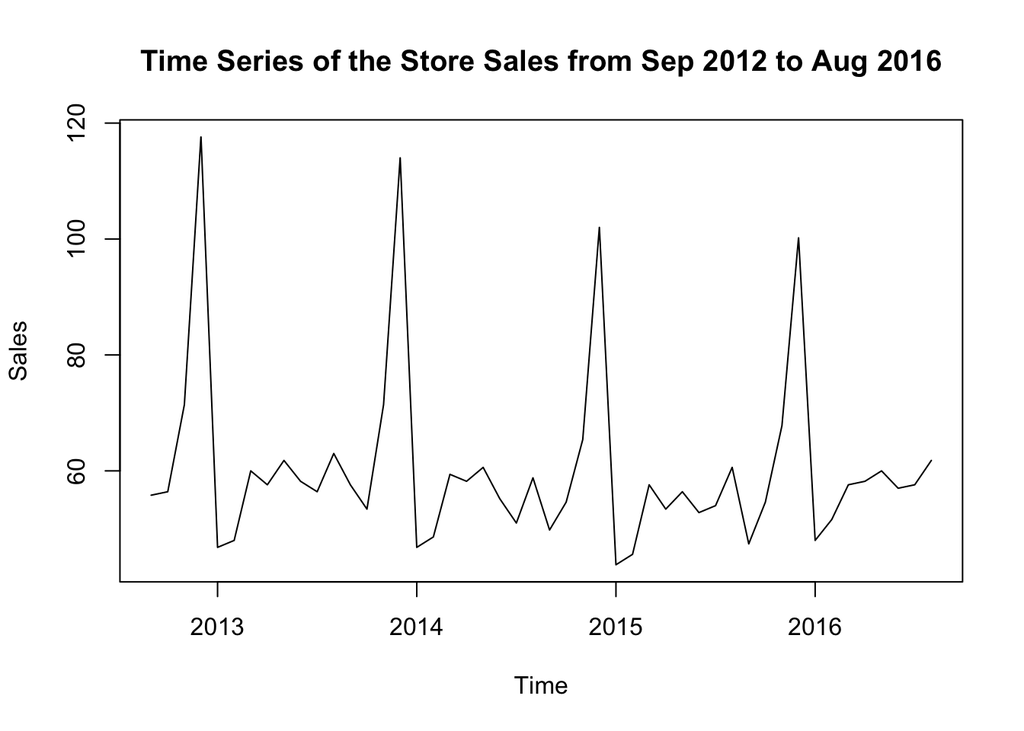

```r
all = df[,7:11] %>%
        as.matrix %>%
        as.numeric %>%
        na.omit %>%
        as.numeric
allts = ts(all, start = c(2012, 9), end = c(2016, 8), frequency = 12)
plot(allts,
     main = "Time Series of the Store Sales from Sep 2012 to Aug 2016",
     ylab = "Sales")
```

```r
allts
```

```
##        Jan   Feb   Mar   Apr   May   Jun   Jul   Aug   Sep   Oct   Nov
## 2012                                                  55.8  56.4  71.4
## 2013  46.8  48.0  60.0  57.6  61.8  58.2  56.4  63.0  57.6  53.4  71.4
## 2014  46.8  48.6  59.4  58.2  60.6  55.2  51.0  58.8  49.8  54.6  65.4
## 2015  43.8  45.6  57.6  53.4  56.4  52.8  54.0  60.6  47.4  54.6  67.8
## 2016  48.0  51.6  57.6  58.2  60.0  57.0  57.6  61.8
##        Dec
## 2012 117.6
## 2013 114.0
## 2014 102.0
## 2015 100.2
## 2016
```

```r
model2 <- auto.arima(allts)
model2_forecast <- forecast(model2, h = 4)
summary(model2_forecast)
```

```
##
## Forecast method: ARIMA(0,1,1)(0,1,0)[12]
##
## Model Information:
## Series: allts
## ARIMA(0,1,1)(0,1,0)[12]
##
## Coefficients:
##           ma1
##       -0.6543
## s.e.   0.1105
##
## sigma^2 estimated as 10.66:  log likelihood=-90.84
## AIC=185.68   AICc=186.06   BIC=188.8
##
## Error measures:
##                     ME     RMSE      MAE       MPE     MAPE      MASE
## Training set 0.1261542 2.747582 1.936778 0.5251476 3.350474 0.6384983
##                     ACF1
## Training set -0.03371436
##
## Forecasts:
##          Point Forecast    Lo 80     Hi 80    Lo 95     Hi 95
## Sep 2016       50.12901 45.94524  54.31278 43.73048  56.52753
## Oct 2016       57.32901 52.90225  61.75577 50.55886  64.09915
## Nov 2016       70.52901 65.87192  75.18610 63.40660  77.65141
## Dec 2016      102.92901 98.05245 107.80556 95.47096 110.38705
```

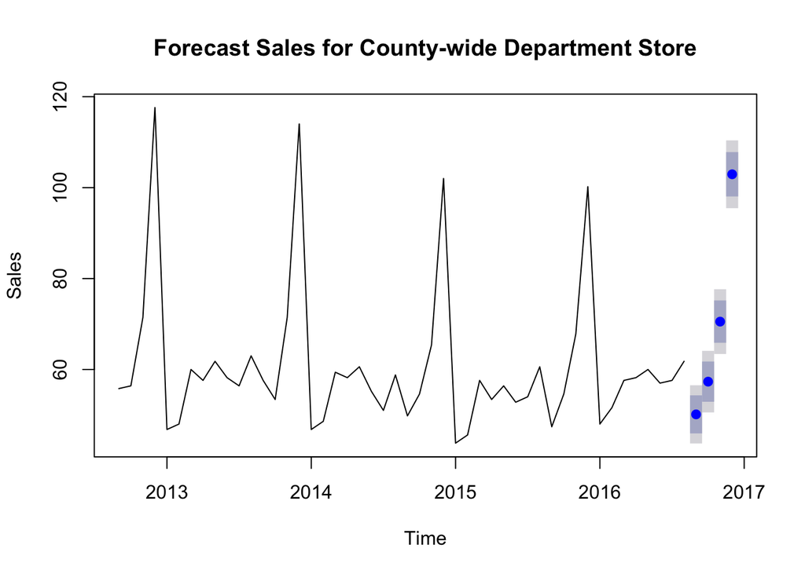

```r
plot(model2_forecast,
     main = "Forecast Sales for County-wide Department Store",
     ylab = "Sales", xlab = "Time")
```

```r
est_all_no_Hurr = 50.12901+57.32901+70.52901+102.92901
est_all_no_Hurr
```

```
## [1] 280.916
```

# 3. (20 pts) An estimate of lost sales for the Carlson Department Store for September through December

```r
sum(model1_forecast$mean)
```

```
## [1] 12.3213
```

## An estimate of lost sale for Carlson Department Store for September through December would be *12.3213*

# 4. (10 pts) Conclude for or against excess storm-related sales for the Carlson Department Store.

```r
allts_sep_dec = ts(all, start = c(2016, 9), end = c(2016, 12), frequency = 12)
carl_Real = model1_forecast$mean*(allts_sep_dec/model2_forecast$mean)
carl_Real #sale of caltson
```

```
##           Sep      Oct      Nov      Dec
## 2016 2.442453 2.578945 3.139889 5.031797
```

```r
sum(carl_Real)
```

```
## [1] 13.19308
```

## So it is excess storm related sales